# NB

MENG

### step1 download dataset [link]（http://www.dt.fee.unicamp.br/~tiago/smsspamcollection/）

```r
setwd('d:/rworkspace/ml')
```

### step2 探索和准备数据

读取数据到sms_raw中

```r
library(readr)

sms_raw <- read_delim("D:/rworkspace/ml/SMSSpamCollection.txt", "\t", escape_double = FALSE, trim_ws = TRUE)
str(sms_raw)
```

```
## Classes 'tbl_df', 'tbl' and 'data.frame':    5572 obs. of  2 variables:
##  $ type: chr  "ham" "ham" "spam" "ham" ...
##  $ text: chr  "Go until jurong point, crazy.. Available only in bugis n great world la e buffet... Cine there got amore wat..." "Ok lar... Joking wif u oni..." "Free entry in 2 a wkly comp to win FA Cup final tkts 21st May 2005. Text FA to 87121 to receive entry question("| __truncated__ "U dun s…
##  - attr(*, "spec")=List of 2
##   ..$ cols   :List of 2
##   .. ..$ type: list()
##   .. .. ..- attr(*, "class")= chr  "collector_character" "collector"
##   .. ..$ text: list()
##   .. .. ..- attr(*, "class")= chr  "collector_character" "collector"
##   ..$ default: list()
##   .. ..- attr(*, "class")= chr  "collector_guess" "collector"
##   ..- attr(*, "class")= chr "col_spec"
```

将sms_raw的类型从字符型变量改成因子型变量

```r
sms_raw$type <- factor(sms_raw$type)
str(sms_raw$type)
```

```
##  Factor w/ 2 levels "ham","spam": 1 1 2 1 1 2 1 1 2 2 ...
```

用table查看type的数据，spam占比约13.4%

```r
table(sms_raw$type)
```

```
##
##  ham spam
## 4825  747
```

#### 处理和分析文本数据

Corpus():创建了一个R对象来存储文本文档 VectorsSource():指示Corpus()函数使用向量sms_raw$text

```r
library(tm)
sms_corpus <- Corpus(VectorSource(sms_raw$text))
print(sms_corpus)
```

```
## <<SimpleCorpus>>
## Metadata:  corpus specific: 1, document level (indexed): 0
## Content:  documents: 5572
```

inspect():查看语料库的内容

```r
inspect(sms_corpus[1:3])
```

```
## <<SimpleCorpus>>
## Metadata:  corpus specific: 1, document level (indexed): 0
## Content:  documents: 3
##
## [1] Go until jurong point, crazy.. Available only in bugis n great world la e buffet... Cine there got amore wat...
## [2] Ok lar... Joking wif u oni...
## [3] Free entry in 2 a wkly comp to win FA Cup final tkts 21st May 2005. Text FA to 87121 to receive entry question(std txt rate)T&C's apply 08452810075over18's
```

change upper letter to lower letter remove numbers remove stopwors() remove punctuation remove space between 2 words

```r
corpus_clean = tm_map(sms_corpus, tolower)
corpus_clean = tm_map(corpus_clean, removeNumbers)
corpus_clean = tm_map(corpus_clean, removeWords, stopwords())
corpus_clean = tm_map(corpus_clean, removePunctuation)
corpus_clean = tm_map(corpus_clean, stripWhitespace)
inspect(corpus_clean[1:3])
```

```
## <<SimpleCorpus>>
## Metadata:  corpus specific: 1, document level (indexed): 0
## Content:  documents: 3
##
## [1] go jurong point crazy available bugis n great world la e buffet cine got amore wat
## [2] ok lar joking wif u oni
## [3] free entry wkly comp win fa cup final tkts st may text fa receive entry questionstd txt ratetcs apply s
```

通过**标记化**过程将消息分解成单个单词组成的组 一个记号（token）就是一个文本字符串的单个元素，本例中token就是单词 DocumentTermMatrix(): 将一个语料库作为输入，并创建一个**稀疏矩阵**的数据结构

```r
# 创建稀疏矩阵
sms_dtm = DocumentTermMatrix(corpus_clean)
```

1. 建立测试和训练数据集

```r
sms_raw_train <- sms_raw[1:4825, ]
sms_raw_test <- sms_raw[4826:5572, ]
```

输入文档-单词矩阵

```r
sms_dtm_train <- sms_dtm[1:4825, ]
sms_dtm_test <- sms_dtm[4826:5572, ]
```

最终语料库

```r
sms_corpus_train <- corpus_clean[1:4825 ]
sms_corpus_test <- corpus_clean[4826:5572 ]
```

ham和spam在test和train中占比差不多，说明分配比较均匀

```r
prop.table(table(sms_raw_train$type))
```

```
##
##       ham      spam
## 0.8654922 0.1345078
```

```r
prop.table(table(sms_raw_test$type))
```

```
##
##       ham      spam
## 0.8688086 0.1311914
```

2. 可视化文本数据-词云 random.order=F: 顺序排列，词频越高，越接近中心 min.freq=40: 在至少40条短信中出现过

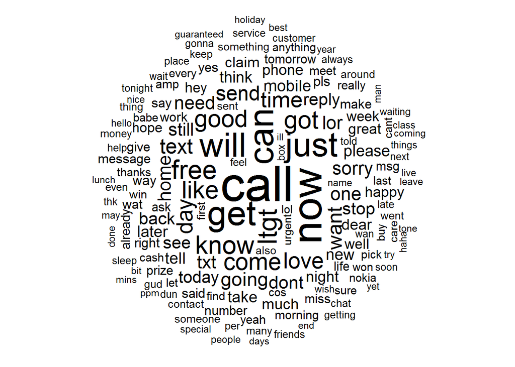

```r
library('wordcloud')
wordcloud(sms_corpus_train, min.freq = 40, random.order = F)
```

在训练集中，对标签为spam和ham分别做图，进行比较。spam中，比较多的是free，prize，推测是垃圾信息

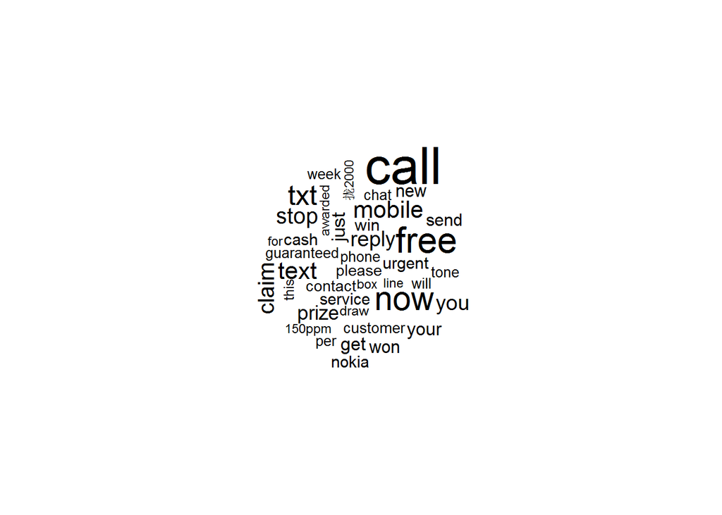

```r
spam = subset(sms_raw_train, type == 'spam')
ham = subset(sms_raw_train, type == 'ham')
wordcloud(spam$text, max.words = 40, scale = c(3, 0.5))
```

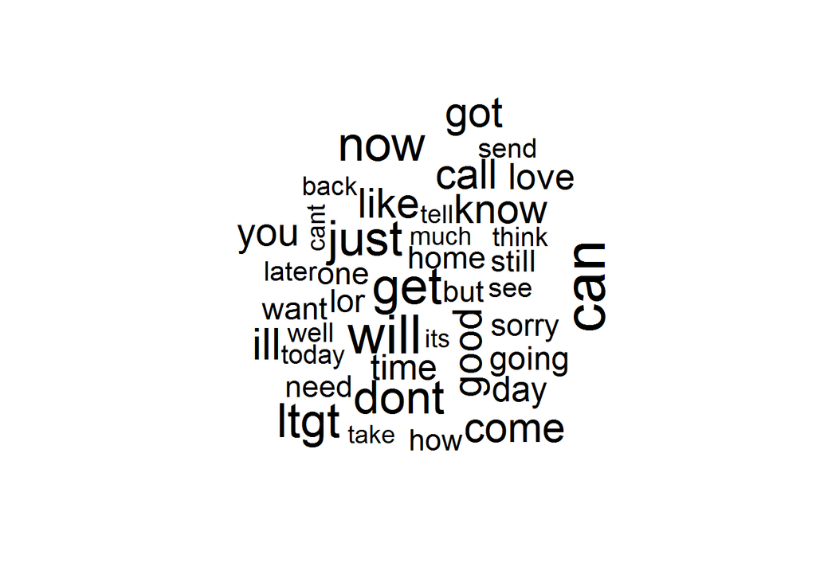

```r
wordcloud(ham$text, max.words = 40, scale = c(3, 0.5))
```

3. 为频繁出现的单词创建指示特征 findFreqTerms(): 输入**文档-单词矩阵**， 返回一个字符向量

```r
# 参数5表示该向量中断的单词在矩阵中至少出现5次，类型是character
sms_dict = findFreqTerms(sms_dtm_train, 5)

#把数据集中所有频率超过5次的单词保存成新的数据集
sms_train = DocumentTermMatrix(sms_corpus_train, list(dictionary = sms_dict))
sms_test = DocumentTermMatrix(sms_corpus_test, list(dictionary = sms_dict))
```

朴素贝叶斯分类器通常是训练具有明确特征的数据。 因为稀疏矩阵中的元素表示一个单词出现的次数，我们需要将其改变成因子变量，根据单词是否出现，简单的表示为yes或者no

```r
# 自定义函数convert_counts()
convert_counts = function(x){
  x = ifelse(x>0, 1, 0)  #x > 0, 用1替换，否则用0替换
  x = factor(x, levels = c(0, 1), labels = c('"No"', '"Yes"'))
  return(x)
  }
```

将convert_counts()应用到每列稀疏矩阵。 apply()来实现，而非for或者while循环

```r
#MARGIN = 1 按行，MARGIN = 2按列
sms_train <- apply(sms_train, MARGIN = 2, convert_counts)
sms_test <- apply(sms_test, MARGIN = 2, convert_counts)
```

### step3 基于数据训练模型

```r
library(e1071)
sms_classifier = naiveBayes(sms_train, sms_raw_train$type)
#class(sms_train)
#class(sms_classifier)
#class(sms_raw_train$type)
```

### step4 评估模型的性能

```r
sms_test_pred = predict(sms_classifier, sms_test)
class(sms_test_pred)
```

```
## [1] "factor"
```

```r
library(gmodels)
CrossTable(sms_test_pred, sms_raw_test$type,prop.chisq = F, prop.t = F, dnn = c('predicted', 'actual'))
```

```
##
##
##    Cell Contents
## |-------------------------|
## |                       N |
## |           N / Row Total |
## |           N / Col Total |
## |-------------------------|
##
##
## Total Observations in Table:  747
##
##
##              | actual
##    predicted |       ham |      spam | Row Total |
## -------------|-----------|-----------|-----------|
##          ham |       647 |        12 |       659 |
##              |     0.982 |     0.018 |     0.882 |
##              |     0.997 |     0.122 |           |
## -------------|-----------|-----------|-----------|
##         spam |         2 |        86 |        88 |
##              |     0.023 |     0.977 |     0.118 |
##              |     0.003 |     0.878 |           |
## -------------|-----------|-----------|-----------|
## Column Total |       649 |        98 |       747 |
##              |     0.869 |     0.131 |           |
## -------------|-----------|-----------|-----------|
##
##
```

```r
sms_classifier2 = naiveBayes(sms_train, sms_raw_train$type, laplace = 1)
sms_test_pred2 = predict(sms_classifier2, sms_test)
CrossTable(sms_test_pred2, sms_raw_test$type, prop.chisq = F, prop.t = F, prop.r=F, dnn = c('predicted','test'))
```

```
##
##
##    Cell Contents
## |-------------------------|
## |                       N |
## |           N / Col Total |
## |-------------------------|
##
##
## Total Observations in Table:  747
##
##
##              | test
##    predicted |       ham |      spam | Row Total |
## -------------|-----------|-----------|-----------|
##          ham |       647 |        17 |       664 |
##              |     0.997 |     0.173 |           |
## -------------|-----------|-----------|-----------|
##         spam |         2 |        81 |        83 |
##              |     0.003 |     0.827 |           |
## -------------|-----------|-----------|-----------|
## Column Total |       649 |        98 |       747 |
##              |     0.869 |     0.131 |           |
## -------------|-----------|-----------|-----------|
##
##
```